# Case Study 5

matthewchapman

2022-09-27

#### Summary for FiveThirtyEight Article

The article describes the data which is more than 33k annual gun deaths in America. The data is only for US residents and excludes non-citizens. It pulled its data from various sources to create the intent category. Homicides is death by assault and legal intervention. Mass shootings are when 3 or more people are killed. Terrorism is data taken from the Global Terrorism Database. Population totals are from Minnesota’s IPUMS project and is based off 2012-2014 survery results.

#### Libararies

```r
library(downloader)
library(dplyr)
library(tidyverse)
```

#### Download Data

```r
data <- read_csv("https://raw.githubusercontent.com/fivethirtyeight/guns-data/master/full_data.csv")
```

```
## ──────────────────────────────────────────────────────── Delimiter: "," chr
## (6): month, intent, sex, race, place, education dbl (5): ...1, year, police,
## age, hispanic
```

```r
data
```

```
## # A tibble: 100,798 × 11
##     ...1  year month intent       police sex     age race  hispa…¹ place educa…²
##    <dbl> <dbl> <chr> <chr>         <dbl> <chr> <dbl> <chr>   <dbl> <chr> <chr>
##  1     1  2012 01    Suicide           0 M        34 Asia…     100 Home  BA+
##  2     2  2012 01    Suicide           0 F        21 White     100 Stre… Some c…
##  3     3  2012 01    Suicide           0 M        60 White     100 Othe… BA+
##  4     4  2012 02    Suicide           0 M        64 White     100 Home  BA+
##  5     5  2012 02    Suicide           0 M        31 White     100 Othe… HS/GED
##  6     6  2012 02    Suicide           0 M        17 Nati…     100 Home  Less t…
##  7     7  2012 02    Undetermined      0 M        48 White     100 Home  HS/GED
##  8     8  2012 03    Suicide           0 M        41 Nati…     100 Home  HS/GED
##  9     9  2012 02    Accidental        0 M        50 White     100 Othe… Some c…
## 10    10  2012 02    Suicide           0 M        NA Black     998 Home  <NA>
## # … with 100,788 more rows, and abbreviated variable names ¹hispanic,
## #   ²education
```

#### Add Age Group to Data

```r
d1 <- data %>%
  mutate(agegroup = case_when(
    age < 15 ~ "under 15",
    age >=15 & age <=34 ~ "15-34",
    age >=35 & age <=64 ~ "35-64",
    age >= 65 ~ "65+"
  )) %>%
  drop_na() %>%
  mutate(agegroup = factor(agegroup, levels=c("under 15", "15-34", "35-64", "65+")))
```

## Plot1

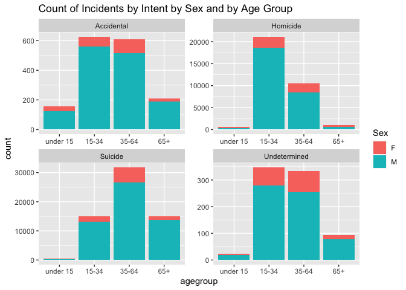

```r
p1 <- ggplot(data = d1, mapping = aes(x = agegroup, fill = sex)) +
  geom_bar() +
  facet_wrap(~ intent, nrow = 2, scales = "free") +
  labs(title = "Count of Incidents by Intent by Sex and by Age Group", fill = "Sex")
p1
```

## Plot2

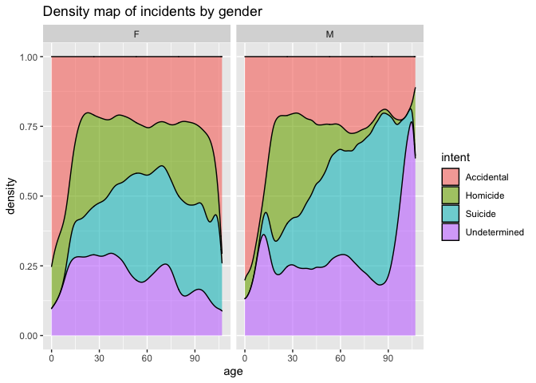

```r
p2 <- ggplot(data = d1, mapping = aes(x=age,fill=intent)) +
  geom_density(alpha = .6,position="fill") +
  facet_wrap(~ sex) +
  labs(title = "Density map of incidents by gender")
p2
```

#### Add seasons to data set for commerical (Plot3)

```r
data1 <- data %>%
  mutate(month = as.integer(month), season = case_when(
    month == "12" | month =="1" | month == "2" ~ "Winter",
    month == "3" | month =="4" | month == "5" ~ "Spring",
    month == "6" | month =="7" | month == "8" ~ "Summer",
    month == "9" | month =="10" | month == "11" ~ "Fall"
  )) %>%
  drop_na()
data1
```

```
## # A tibble: 98,015 × 12
##     ...1  year month intent       police sex     age race  hispa…¹ place educa…²
##    <dbl> <dbl> <int> <chr>         <dbl> <chr> <dbl> <chr>   <dbl> <chr> <chr>
##  1     1  2012     1 Suicide           0 M        34 Asia…     100 Home  BA+
##  2     2  2012     1 Suicide           0 F        21 White     100 Stre… Some c…
##  3     3  2012     1 Suicide           0 M        60 White     100 Othe… BA+
##  4     4  2012     2 Suicide           0 M        64 White     100 Home  BA+
##  5     5  2012     2 Suicide           0 M        31 White     100 Othe… HS/GED
##  6     6  2012     2 Suicide           0 M        17 Nati…     100 Home  Less t…
##  7     7  2012     2 Undetermined      0 M        48 White     100 Home  HS/GED
##  8     8  2012     3 Suicide           0 M        41 Nati…     100 Home  HS/GED
##  9     9  2012     2 Accidental        0 M        50 White     100 Othe… Some c…
## 10    11  2012     2 Suicide           0 M        30 White     100 Home  Some c…
## # … with 98,005 more rows, 1 more variable: season <chr>, and abbreviated
## #   variable names ¹hispanic, ²education
```

## Plot3

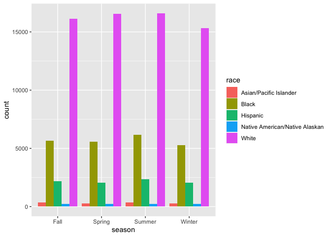

```r
p3 <- ggplot(data = data1, mapping = aes(x = season, fill = race)) +
  geom_bar(position = "dodge")
p3
```

Plot 3 shows the count of incidents by season and race. The plot shows that their is not a significant difference between total number of incidents and the season. Each race also has a simiolar number of incidents in each season. The data does show that white people were involved in more incidents than anybody. Next was black, and then hispanic.

#### Only Use winter and summer data (Plot 4)

```r
d2 <- data1 %>%
  filter(season == "Winter" | season == "Summer")
d2
```

```
## # A tibble: 48,805 × 12
##     ...1  year month intent       police sex     age race  hispa…¹ place educa…²
##    <dbl> <dbl> <int> <chr>         <dbl> <chr> <dbl> <chr>   <dbl> <chr> <chr>
##  1     1  2012     1 Suicide           0 M        34 Asia…     100 Home  BA+
##  2     2  2012     1 Suicide           0 F        21 White     100 Stre… Some c…
##  3     3  2012     1 Suicide           0 M        60 White     100 Othe… BA+
##  4     4  2012     2 Suicide           0 M        64 White     100 Home  BA+
##  5     5  2012     2 Suicide           0 M        31 White     100 Othe… HS/GED
##  6     6  2012     2 Suicide           0 M        17 Nati…     100 Home  Less t…
##  7     7  2012     2 Undetermined      0 M        48 White     100 Home  HS/GED
##  8     9  2012     2 Accidental        0 M        50 White     100 Othe… Some c…
##  9    11  2012     2 Suicide           0 M        30 White     100 Home  Some c…
## 10    12  2012     1 Suicide           0 M        21 Nati…     100 Home  HS/GED
## # … with 48,795 more rows, 1 more variable: season <chr>, and abbreviated
## #   variable names ¹hispanic, ²education
```

## Plot4

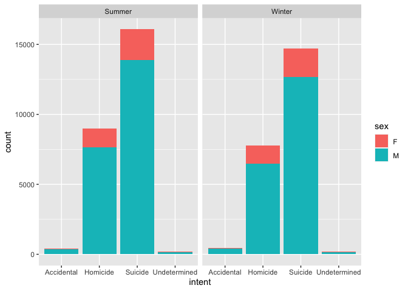

```r
p4 <- ggplot(data = d2, mapping = aes(x = intent, fill = sex)) +
  geom_bar() +
  facet_wrap(~ season)
p4
```